# Mann-Whitney-Wilcoxon Test Exercises

Exercícios de teste de Mann-Whitney-Wilcoxon Vamos explorar as propriedades das estatísticas robustas. Usaremos um dos conjuntos de dados incluídos em R, que contém o peso dos pintinhos em gramas à medida que crescem do dia 0 ao dia 21. Esse conjunto de dados também divide os pintinhos por diferentes dietas protéicas, que são codificadas de 1 a 4. Usamos este conjunto de dados também mostra uma operação importante em R (não relacionada a resumos robustos): remodelar.

Este conjunto de dados está integrado em R e pode ser carregado com:

|  | weight | Time | Chick | Diet |
| --- | --- | --- | --- | --- |
| 1 | 42 | 0 | 1 | 1 |
| 2 | 51 | 2 | 1 | 1 |
| 3 | 59 | 4 | 1 | 1 |
| 4 | 64 | 6 | 1 | 1 |
| 5 | 76 | 8 | 1 | 1 |
| 6 | 93 | 10 | 1 | 1 |

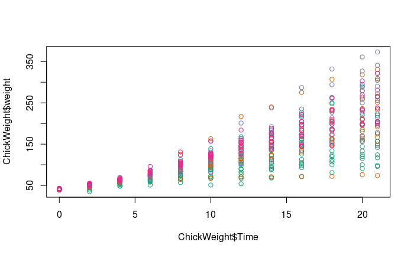

```r
plot( ChickWeight$Time, ChickWeight$weight, col=ChickWeight$Diet)
```

Primeiro, observe que as linhas aqui representam pontos no tempo e não indivíduos. Para facilitar a comparação de pesos em diferentes momentos e entre os diferentes pintinhos, remodelaremos os dados para que cada linha seja um pintinho. Em R podemos fazer isso com a função remodelar:

|  | Chick | Diet | weight.0 | weight.2 | weight.4 | weight.6 | weight.8 | weight.10 | weight.12 | weight.14 | weight.16 | weight.18 | weight.20 | weight.21 |
| --- | --- | --- | --- | --- | --- | --- | --- | --- | --- | --- | --- | --- | --- | --- |
| 1 | 1 | 1 | 42 | 51 | 59 | 64 | 76 | 93 | 106 | 125 | 149 | 171 | 199 | 205 |
| 13 | 2 | 1 | 40 | 49 | 58 | 72 | 84 | 103 | 122 | 138 | 162 | 187 | 209 | 215 |
| 25 | 3 | 1 | 43 | 39 | 55 | 67 | 84 | 99 | 115 | 138 | 163 | 187 | 198 | 202 |
| 37 | 4 | 1 | 42 | 49 | 56 | 67 | 74 | 87 | 102 | 108 | 136 | 154 | 160 | 157 |
| 49 | 5 | 1 | 41 | 42 | 48 | 60 | 79 | 106 | 141 | 164 | 197 | 199 | 220 | 223 |
| 61 | 6 | 1 | 41 | 49 | 59 | 74 | 97 | 124 | 141 | 148 | 155 | 160 | 160 | 157 |

```r
chick = na.omit(chick)
```

Exercícios de teste Mann-Whitney-Wilcoxon nº 1

Salve os pesos dos pintinhos no dia 4 da dieta 1 como um vetor x. Salve os pesos dos pintinhos no dia 4 da dieta 4 como um vetor y. Realize um teste t comparando xe y(em R a função t.test(x,y)realizará o teste). Em seguida, execute um teste de Wilcoxon xe y(em R a função wilcox.test(x,y)realizará o teste). Aparecerá um aviso de que um valor p exato não pode ser calculado com empates, portanto, é usada uma aproximação, o que é adequado para nossos propósitos.

Realize um teste t de xe y, após adicionar um único pintinho com peso de 200 gramas x(à dieta 1 pintinhos). Qual é o valor p deste teste? O valor p de um teste está disponível com o seguinte código:t.test(x,y)$p.value

```r
x = chick$weight.4[chick$Diet == 1]
y = chick$weight.4[chick$Diet == 4]
t.test(c(x, 200), y)$p.value
```

```
[1] 0.9380347
```

Exercícios de teste Mann-Whitney-Wilcoxon nº 2

Faça o mesmo para o teste de Wilcoxon. O teste de Wilcoxon é robusto ao outlier. Além disso, tem menos suposições que o teste t sobre a distribuição dos dados subjacentes.

```r
x = chick$weight.4[chick$Diet == 1]
y = chick$weight.4[chick$Diet == 4]
wilcox.test(c(x, 200), y, exact=FALSE)$p.value
```

```
[1] 0.0009840921
```

Exercícios de teste Mann-Whitney-Wilcoxon nº 3

Iremos agora investigar uma possível desvantagem da estatística do teste Wilcoxon-Mann-Whitney. Usando o código a seguir para fazer três boxplots, mostrando os verdadeiros pesos da Dieta 1 vs 4 e, em seguida, duas versões alteradas: uma com diferença adicional de 10 gramas e outra com diferença adicional de 100 gramas. Use xey conforme definido acima, NÃO aqueles com valores discrepantes adicionados.

```r
library(rafalib)

x = chick$weight.4[chick$Diet == 1]
y = chick$weight.4[chick$Diet == 4]

mypar(1,3)
boxplot(x,y)
boxplot(x,y+10)
```

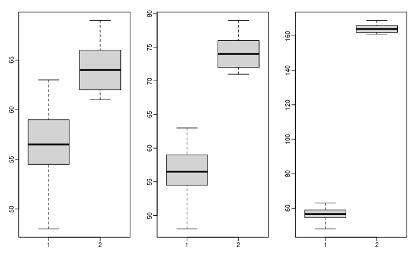

```r
boxplot(x,y+100)
```

Qual é a diferença na estatística do teste t (obtida t.test(x,y)$statistic)entre a adição de 10 e a adição de 100 a todos os valores no grupo ‘y’? Pegue a estatística do teste t com xey + 10 e subtraia a estatística do teste t com xey + 100. O valor deve ser positivo.

```r
t.test(x,y+10)$statistic - t.test(x,y+100)$statistic
```

```
       t
67.75097
```